# test_brain

Feiyang ZHANG

2023-04-05

# 1 Processing Seurat Object

We will use `major_clust` as the Ident.

```r
snRNA.hpfc.sct$major_clust %>% table()
```

```
## .
##       Astro       Oligo  LAMP5_NOS1         OPC   L2-3_CUX2   L5-6_TLE4
##        3334       10026         118        1691        3343         451
##       Micro L5-6_THEMIS         SST   PV_SCUBE3         VIP         ID2
##        1280         329        1001         137         820         689
##          PV     L4_RORB         Vas      PN_dev
##         558         729          57           1
```

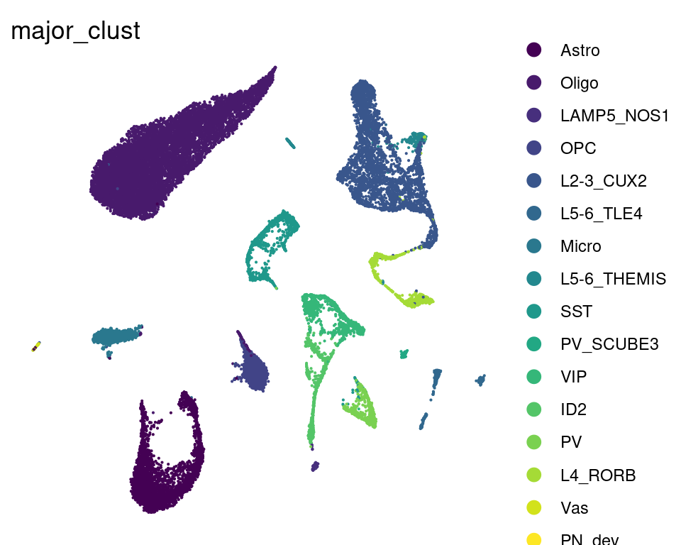

```r
#snRNA.hpfc.sct <- FindVariableFeatures(snRNA.hpfc.sct,nfeatures = 3000)

(p <- DimPlot(snRNA.hpfc.sct,group.by = "major_clust") + scale_color_manual(values = colors.brain) + theme_void())
```

# 2 Calculation Time

## 2.1 Test of the calculation time of starTracer

### run time test

we choose `thresh.1` = 0.5 (by default)，`thresh.2` = 0.3， `num` = 2

explanations of parameters:

1. `thresh.1`: The threshold to decide a cluster goes to the group where it might become a positive marker or group where it might be a negative marker, for each gene included.
2. `thresh.2`: The threshold to filter out the lowest thresh.2 (by percentage) in each group after assigning genes into clusters.
3. `num`: The number of marker genes in the output matrix for each cluster

```r
Idents(snRNA.hpfc.sct) <- snRNA.hpfc.sct$major_clust
t.Star <- c()
for(i in 1:10){
  print(paste0("calculating time:",i))
  t1 <- Sys.time()
  starTracer::searchMarker(snRNA.hpfc.sct,thresh.1 = 0.5,thresh.2 = 0.3,method = "del_MI",num = 2,gene.use = "HVG")
  t2 <- Sys.time()
  t <- t2-t1 #10.99338/10.1306 secs 12.34614/12.43914/11.35643 for HVG
  t.Star <- append(t.Star,t)
}
t.Star.brain <- t.Star
#save(t.Star.brain,file = "./out/f1_brain/t.Star.brain.Rdata")
```

the results of executing time

```r
t.Star.brain
```

```
## Time differences in secs
##  [1] 11.362641 11.785273 11.967402 10.830096 10.703633 10.859631  9.946597
##  [8] 10.060771 10.211165 10.208731
```

### Visualization of top 3 marker genes

We choose top 3 marker genes when performing visualization

> Note that: the value of `num` will **NOT** influence the calculation speed significantly. Because `searchMarker` will automatically calculate all the potential marker genes and only output the topN marker for each cluster, which will be specified by the user with `num`.

We run `searchMarker` again by setting `num` to 3 for visualization.

```r
out.brain.Star <- starTracer::searchMarker(snRNA.hpfc.sct,thresh.1 = 0.5,thresh.2 = 0.3,method = "del_MI",num = 3,gene.use = "HVG")
```

```
## using Astro, Oligo, LAMP5_NOS1, OPC, L2-3_CUX2, L5-6_TLE4, Micro, L5-6_THEMIS, SST, PV_SCUBE3, VIP, ID2, PV, L4_RORB, Vas, PN_dev as ident...
```

```
## using HVG as input features...
```

```
## max normalizing the matirx...
```

```
## screen genes in each cluster according to thresh.2
```

```
## calculating parameters...
```

```
## Using "RNA" as the assay to plot Heatmap...
```

```
## createing out put data...
```

```
## Analysing Complete!
```

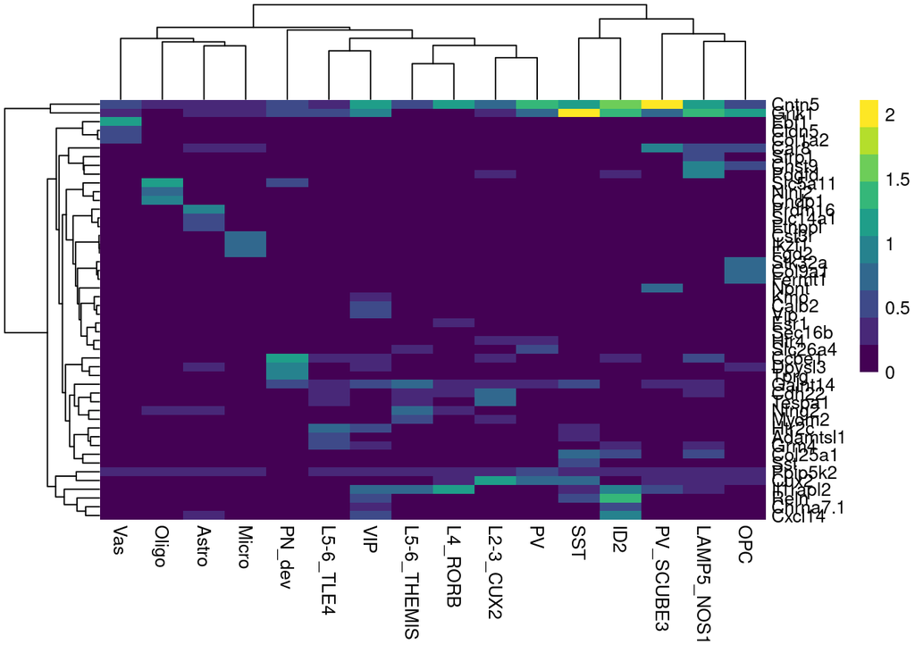

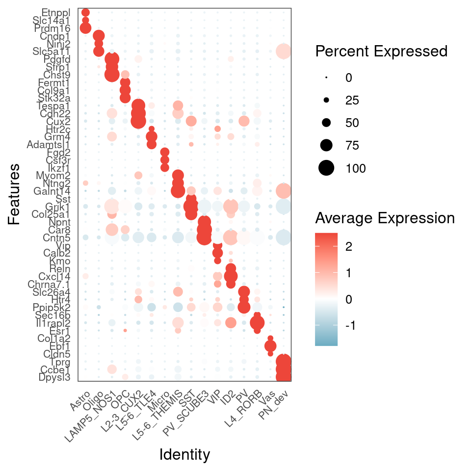

```r
(p <- use_dotplot(snRNA.hpfc.sct,features = out.brain.Star$genes.markers, colors.gradient = c("#018daa","#ffffff","#ed463a")))
```

```r
out.brain.Star.all <- starTracer::searchMarker(snRNA.hpfc.sct,thresh.1 = 0.5,thresh.2 = 0.3,method = "del_MI",num = 3)
```

```
## using Astro, Oligo, LAMP5_NOS1, OPC, L2-3_CUX2, L5-6_TLE4, Micro, L5-6_THEMIS, SST, PV_SCUBE3, VIP, ID2, PV, L4_RORB, Vas, PN_dev as ident...
```

```
## using all genes as input features...
```

```
## max normalizing the matirx...
```

```
## screen genes in each cluster according to thresh.2
```

```
## calculating parameters...
```

```
## Using "RNA" as the assay to plot Heatmap...
```

```
## createing out put data...
```

```
## Analysing Complete!
```

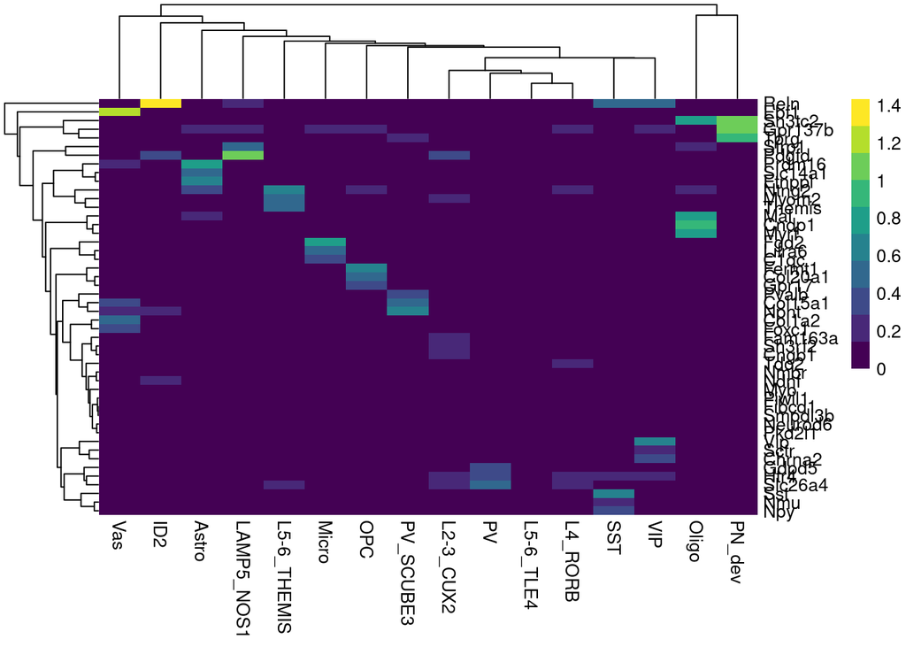

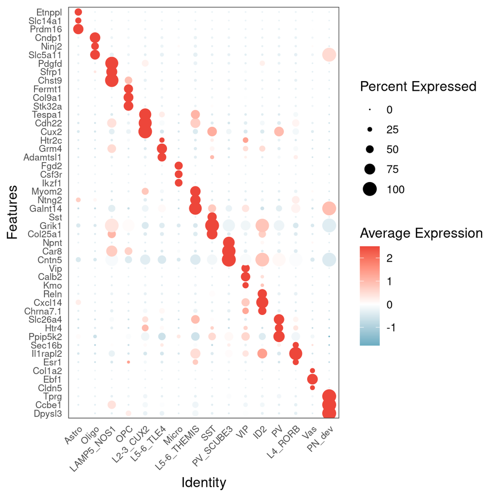

```r
(p <- use_dotplot(snRNA.hpfc.sct,features = out.brain.Star$genes.markers, colors.gradient = c("#018daa","#ffffff","#ed463a")))
```

## 2.2 The calculation time of Seurat

```r
t.Seurat.brain <- c()
for(i in 1:11){
  if(i <= 10){
    print(paste0("calculating time:",i))
    t1 <- Sys.time()
    FindAllMarkers(snRNA.hpfc.sct,logfc.threshold = 0.5,only.pos = T)
    t2 <- Sys.time()
    t <- t2-t1 #10.99338/10.1306 secs 12.34614/12.43914/11.35643 for HVG
    t.Seurat.brain <- append(t.Seurat.brain,t)
  } else {
    out.brain.Seurat <- FindAllMarkers(snRNA.hpfc.sct,logfc.threshold = 0.5,only.pos = T)
  }
}
```

the calculation time of `Seurat` and `starTracer`

```r
t.Seurat.brain # in minutes
```

```
## Time differences in mins
##  [1] 9.430880 9.579019 9.539514 9.406597 9.393570 9.360261 9.307910 9.280949
##  [9] 9.271110 9.240722
```

```r
t.Star.brain # in seconds
```

```
## Time differences in secs
##  [1] 11.362641 11.785273 11.967402 10.830096 10.703633 10.859631  9.946597
##  [8] 10.060771 10.211165 10.208731
```

## 2.3 Difference of calculation time of Seurat and starTracer

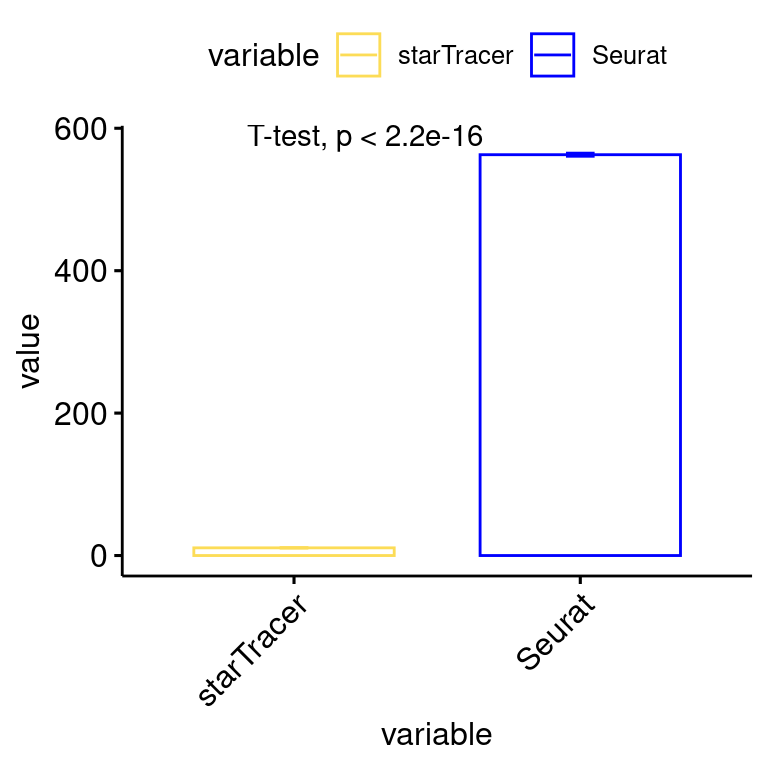

```r
time.1 <- as.numeric(t.Seurat.brain) * 60
time.2 <- as.numeric(t.Star.brain)
frame.time <- data.frame(starTracer = time.2, Seurat = time.1)
frame.time$RunTime <- 1:10 %>% as.vector()
mat.use <- reshape2::melt(frame.time,id = "RunTime")
(p <- ggbarplot(mat.use, x = "variable", y = "value", add = c("mean_se"),color = "variable",fill = "white",palette = c("#fcdc57","blue"),stat = "identity",
          position = position_dodge(0.8)) + stat_compare_means(method = "t.test") + theme(axis.text.x = element_text(angle = 45,hjust = 1)))
```

```r
(fc <- mean(time.1)/mean(time.2))
```

```
## [1] 52.14789
```

# 3 Specificity

## 3.1 Specificity of the Top5 marker genes of starTracer

### Calculate the top5 marker genes for Ti calculation

We will run the `seachMarker` function again. This time we choose to get 5 marker genes in each group. This result will be used to calculate Ti in each cluster.

Ti is defined as

$$T_i=\frac{\mathrm{card}\ \left(\mathrm{G}_\mathrm{i}\mathrm{\cap}\
\mathrm{G}_{\mathrm{clust}}\right)}{\mathrm{card}\left(\mathrm{G}_\mathrm{i}\right)}$$

Where:

Gi represents the set of the cells expressing gene i *in-silico*.

Gclust represents the set of cells where gene i serves as the *in-silico* marker gene.

Please refer to our original research article to see more details.

```r
out.brain.Star.5 <- starTracer::searchMarker(snRNA.hpfc.sct,thresh.1 = 0.5,thresh.2 = 0.3,method = "del_MI",num = 5,gene.use = "HVG")
```

```
## using Astro, Oligo, LAMP5_NOS1, OPC, L2-3_CUX2, L5-6_TLE4, Micro, L5-6_THEMIS, SST, PV_SCUBE3, VIP, ID2, PV, L4_RORB, Vas, PN_dev as ident...
```

```
## using HVG as input features...
```

```
## max normalizing the matirx...
```

```
## screen genes in each cluster according to thresh.2
```

```
## calculating parameters...
```

```
## Using "RNA" as the assay to plot Heatmap...
```

```
## createing out put data...
```

```
## Analysing Complete!
```

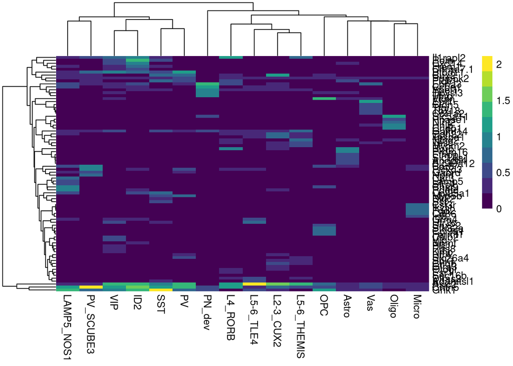

### calculate specificity measured by Ti

calculating specificity level defined by Ti might be time consuming especially for large data set. Ti is calculated by function `cal_spe`. Please refer to “`function.R`” for more details.

```r
frame.star <- subset(out.brain.Star.5$para_frame,out.brain.Star.5$para_frame$gene %in% out.brain.Star.5$genes.markers)[,c("max.X","gene")]
colnames(frame.star)[1] <- "cluster"

frame.star <- cal_spe(snRNA.hpfc.sct,ident.use = "major_clust",frame.star)
```

save files

```r
save(frame.star,file = "./out/f1_brain/frame.star.Rdata")
```

chech the results of frame.star

```r
frame.star %>% head()
```

```
##          cluster     gene   pct.pos
## Etnppl     Astro   Etnppl 0.8747191
## Slc14a1    Astro  Slc14a1 0.8821429
## Prdm16     Astro   Prdm16 0.8574027
## Slc39a12   Astro Slc39a12 0.8553314
## Angptl4    Astro  Angptl4 0.7062999
## Cndp1      Oligo    Cndp1 0.8946529
```

## 3.2 Frame of Seurat

Generating the frame of Seurat:

1. Find marker genes using FindAllMarkers function.
2. Subset the matrix by setting p-value < 0.05
3. re-arrange the data.frame by cluster and descending average log2(Fold-Change)
4. Keep the top 10 marker gene in each cluster

The reason we choose top 10 marker genes: The marker gene results of Seurat might be redundant, which means that a gene might be identified as a marker in more than one cluster. Thus we will keep 10 marker genes in this step to make sure each cluster has more than 5 marker genes. Note that the number 10 is not compulsory.

The Rdata file containing the results of Seurat has already been calculated in Chap #2

```r
load("./out/f1_brain/markers.Seurat.Rdata") #the variable's name will be out.brain.Seurat
```

```r
gene.seurat <- subset(out.brain.Seurat,out.brain.Seurat$p_val_adj < 0.05)
gene.seurat <- arrange(gene.seurat,cluster,desc(avg_log2FC))
gene.seurat <- with(gene.seurat,by(gene.seurat[,"gene"],INDICES = cluster,FUN = function(x)head(x,10))) %>% unlist() %>% as.vector() %>% rev()

gene.seurat %>% head()
```

```
## [1] "Arhgap29" "Rbms3"    "Lama2"    "Itih5"    "Abcb1b"   "Atp10a"
```

We then re-arrange the marker gene data.frame. As for the genes that occurs in more than one cluster, we will only keep it in the cluster that has larger avg_log2FC.

```r
frame.seurat <- out.brain.Seurat[,c("cluster","gene","avg_log2FC")] %>% subset(out.brain.Seurat$gene %in% gene.seurat)
frame.seurat <- arrange(frame.seurat,gene,desc(avg_log2FC))
frame.seurat <- frame.seurat[!duplicated(frame.seurat$gene),] %>% arrange(cluster,desc(avg_log2FC))

frame.seurat <- frame.seurat %>%
  group_by(cluster) %>% #group by cluster
  top_n(5, wt = avg_log2FC) %>% #arrange by FC
  ungroup()
frame.seurat$cluster %>% table()
```

```
## .
##       Astro       Oligo  LAMP5_NOS1         OPC   L2-3_CUX2   L5-6_TLE4
##           5           5           5           5           5           5
##       Micro L5-6_THEMIS         SST   PV_SCUBE3         VIP         ID2
##           5           5           5           5           5           5
##          PV     L4_RORB         Vas      PN_dev
##           5           5           5           0
```

```r
#We will choose the top 3 marker gene to visualize:
frame.seurat.p <- frame.seurat %>%
  group_by(cluster) %>%
  top_n(3, wt = avg_log2FC) %>% #choose the top 3
  ungroup()
frame.seurat.p$cluster %>% table()
```

```
## .
##       Astro       Oligo  LAMP5_NOS1         OPC   L2-3_CUX2   L5-6_TLE4
##           3           3           3           3           3           3
##       Micro L5-6_THEMIS         SST   PV_SCUBE3         VIP         ID2
##           3           3           3           3           3           3
##          PV     L4_RORB         Vas      PN_dev
##           3           3           3           0
```

However, we can not find marker genes for PN_dev

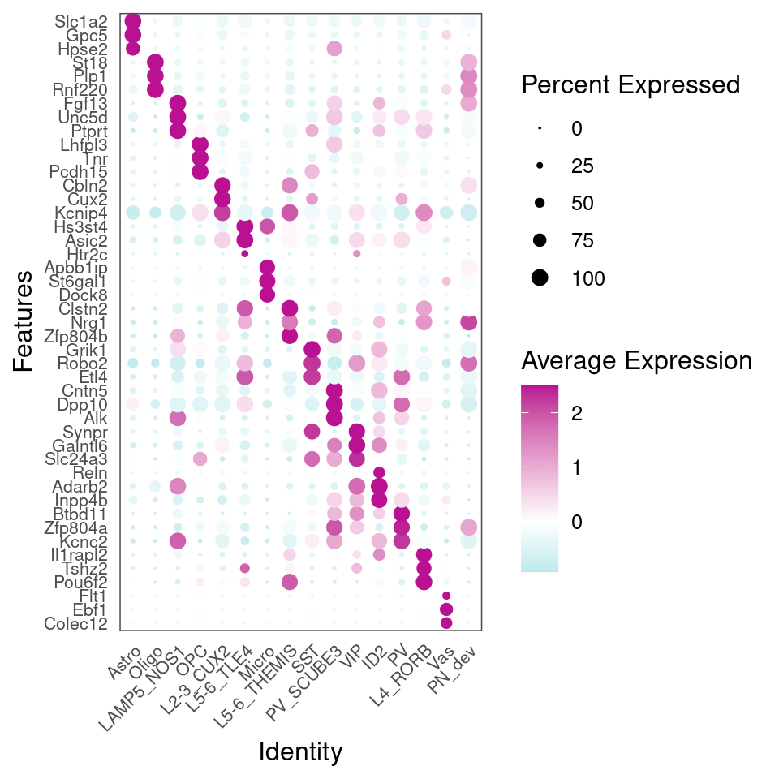

```r
(p <- use_dotplot(snRNA.hpfc.sct,features = rev(frame.seurat.p$gene), colors.gradient = c("#13c4cd","#ffffff","#b91192"),dot.scale = 3))
```

## 3.3 The Specificity Level Measured by Ti Among Two Softwares

calculate the specificity level measured by Ti

```r
frame.seurat <- frame.seurat[,c("cluster","gene")]
frame.seurat <- cal_spe(snRNA.hpfc.sct,ident.use = "major_clust",as.data.frame(frame.seurat))
```

```r
save(frame.seurat,file = "./out/f1_brain/frame.seurat.Rdata")
```

```r
load("./out/f1_brain/frame.seurat.Rdata")
```

Calculate the difference

```r
frame.star <- subset(frame.star,frame.star$cluster %in% frame.seurat$cluster)
identical(frame.star$cluster,frame.seurat$cluster)
```

```
## [1] TRUE
```

We use `frame.pct.pos` to store the top 5 marker genes specificity level from 2 algorithms and store the results in `frame.pct.pos.stat` .

```r
frame.pct.pos <- data.frame(cluster = frame.star$cluster,pct.star = frame.star$pct.pos,pct.seurat = frame.seurat$pct.pos)
```

During the calculation, we will normalize the specificity level to Seurat, which means the mean specificity level will be 1. Meanwhile, only the top 5 marker gene in Seurat will be retained. More specifically:

1. Calculate the mean value of marker gene’s Ti in each group of Seurat (denoted as mean.Seurat).
2. In each cluster, normalize the Ti of marker genes from both starTracer and Seurat to the mean.Seurat (denoted as star.adj and seurat.adj). Notice that the mean value of seurat.adj will be close to 1.
3. Arrange the order of the matrix by descending star.adj.
4. Fold-change will be calculated using the original Ti from starTracer and Seurat. P-value will be calculated using t-test.

We didn’t include the t-test result in our research even though most of the data shows a significant difference: The marker genes found by starTracer and Seurat are different genes identified by 2 different algorithm, which are not samples from some population, so, the H0 may not be defined.

```r
frame.pct.pos <- data.frame(cluster = frame.star$cluster,pct.star = frame.star$pct.pos,pct.seurat = frame.seurat$pct.pos)

#cal seurat.mean
frame.pct.pos$pct.seurat.mean <- rep(aggregate(pct.seurat ~ cluster, data = frame.pct.pos, FUN = mean)$pct.seurat,each = 5)

#divide seurat.mean to get star.adj and seurat.adj
frame.pct.pos$pct.seurat.adj <- frame.pct.pos$pct.seurat/frame.pct.pos$pct.seurat.mean
frame.pct.pos$pct.star.adj <- frame.pct.pos$pct.star/frame.pct.pos$pct.seurat.mean

#cal star.adj.mean to arrange the plot
frame.pct.pos$pct.star.adj.mean <- rep(aggregate(pct.star.adj ~ cluster, data = frame.pct.pos, FUN = mean)$pct.star.adj,each = 5)

#arrange
frame.pct.pos <- arrange(frame.pct.pos,desc(pct.star.adj.mean))
frame.pct.pos$cluster <- factor(frame.pct.pos$cluster,levels = unique(frame.pct.pos$cluster))

p <- c()
foldchange <- c()
for (i in unique(frame.pct.pos$cluster)){
  mat <- subset(frame.pct.pos,cluster == i)
  t1 <- mat$pct.star
  t2 <- mat$pct.seurat
  p.i <- t.test(t1,t2)$p.value
  foldchange.i <- mean(mat$pct.star)/mean(mat$pct.seurat)

  foldchange <- append(foldchange,foldchange.i)
  p <- append(p,p.i)
}
frame.pct.pos.stat <- data.frame(cluster = unique(frame.pct.pos$cluster),p = p, foldchange = foldchange)
```

the specificity level measured by Ti

```r
mat.use <- reshape2::melt(frame.pct.pos[,c(1,5,6)])
```

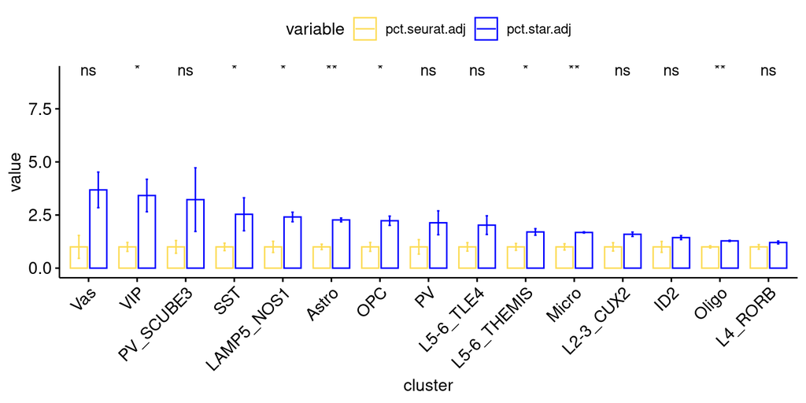

```r
(p <- ggbarplot(mat.use, x = "cluster", y = "value", add = c("mean_se"),color = "variable",fill = "white",palette = c("#fcdc57","blue"),
          position = position_dodge(0.8)) + stat_compare_means(aes(group = variable), label = "p.signif",methods = "wilcox") + theme(axis.text.x = element_text(angle = 45,hjust = 1)))
```